# Prediction On Resale Flat Price

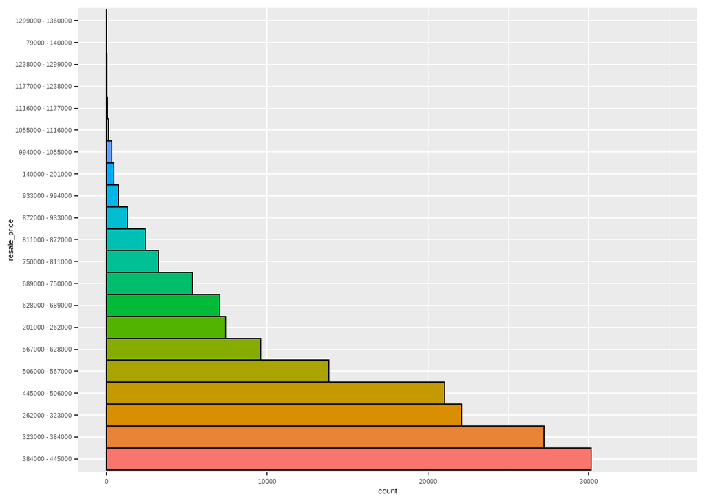

```r
p <- ggplot(data, aes(x = fct_infreq(resale_price_bins), fill = fct_infreq(resale_price_bins))) +
  geom_bar(width = 1, colour = "black", show.legend = FALSE) +
  xlab("resale_price")

p + coord_flip() + scale_y_continuous(limit = c(0, 35000))
```

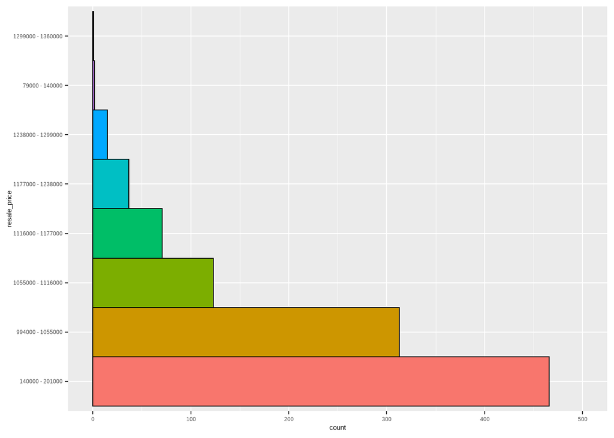

```r
# Zoom in
data_filter <- data %>%
  group_by(resale_price_bins) %>%
  filter(n() < 500)

p <- ggplot(data_filter, aes(x = fct_infreq(resale_price_bins), fill = fct_infreq(resale_price_bins))) +
  geom_bar(width = 1, colour = "black", show.legend = FALSE) +
  xlab("resale_price")

p + coord_flip() + scale_y_continuous(limit = c(0, 500))
```

- Resale price ranges from 384000-445000 has the highest transaction records, more than 30,000 rows
- Resale price ranges from 1299000-1360000 has the lowest transaction records, less than 50 rows
- Most of the HDB resale with price ranges from 262000-567000

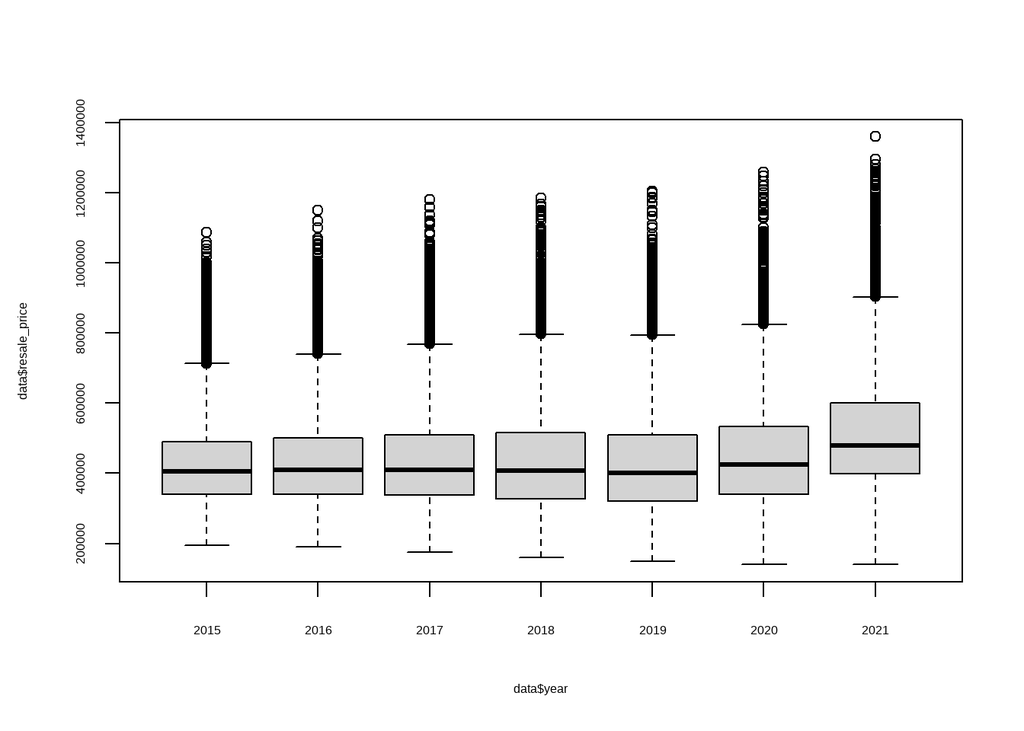

```r
boxplot(data$resale_price ~ data$year)
```

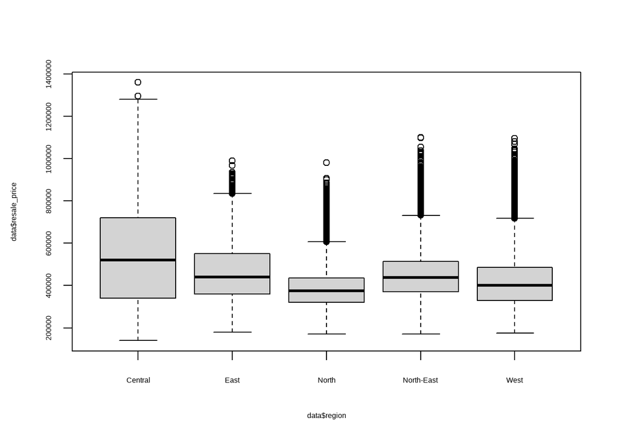

```r
boxplot(data$resale_price ~ data$region)
```

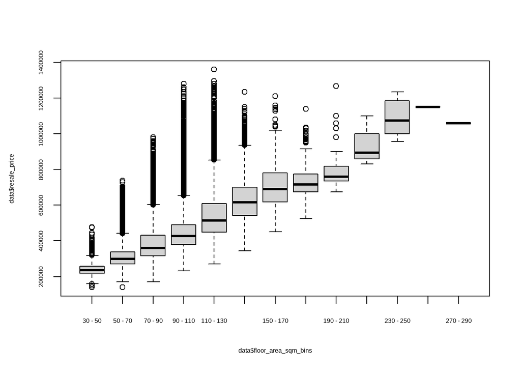

```r
boxplot(data$resale_price ~ data$floor_area_sqm_bins)
```

- correlation between two variables

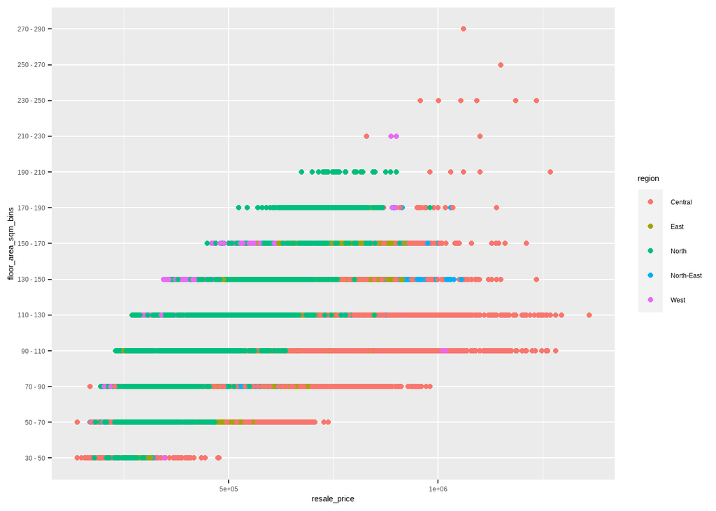

```r
ggplot(data) +
  aes(x = resale_price, y = floor_area_sqm_bins, colour = region) +
  geom_point() +
  scale_color_hue()
```

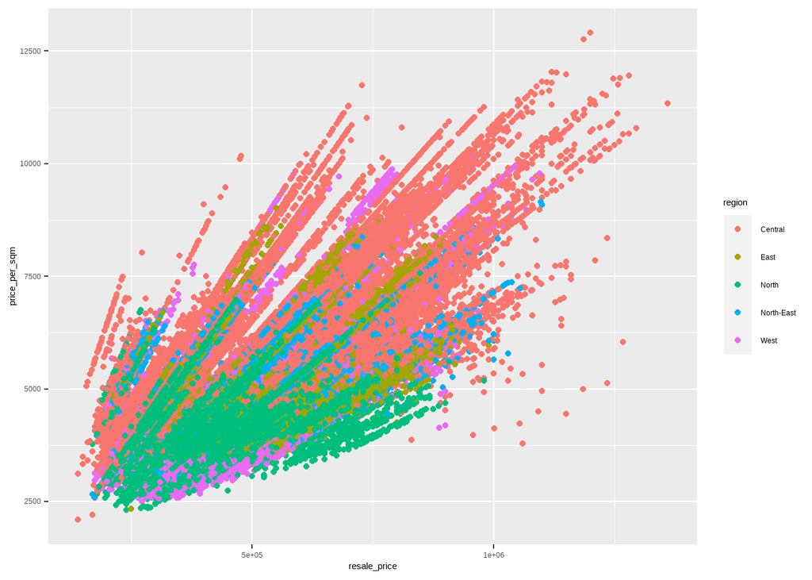

```r
ggplot(data) +
  aes(x = resale_price, y = price_per_sqm, colour = region) +
  geom_point() +
  scale_color_hue()
```

### 11. remaining_lease

```r
head(data$remaining_lease)
```

```
## [1] "70" "65" "64" "63" "64" "64"
```

```r
tail(data$remaining_lease)
```

```
## [1] "65 years"           "66 years"           "65 years 01 month"
## [4] "65 years 10 months" "65 years 01 month"  "65 years 01 month"
```

```r
str(data$remaining_lease)
```

```
##  chr [1:152455] "70" "65" "64" "63" "64" "64" "64" "65" "62" "69" "60" "64" ...
```

```r
data %>% summarise(na = sum(is.na(remaining_lease)))
```

```
##   na
## 1  0
```

```r
summary(data$remaining_lease)
```

```
##    Length     Class      Mode
##    152455 character character
```

- standardize to years

```r
data$used_lease <- data$int_year - data$lease_commence_date

data$remaining_lease <- as.integer(99 - data$used_lease)

data %>% summarise(na = sum(is.na(remaining_lease)))
```

```
##   na
## 1  0
```

```r
summary(data$remaining_lease)
```

```
##    Min. 1st Qu.  Median    Mean 3rd Qu.    Max.
##   44.00   65.00   74.00   74.78   84.00   98.00
```

```r
str(data$remaining_lease)
```

```
##  int [1:152455] 70 65 64 63 64 64 64 65 62 69 ...
```

- exploration by plotting

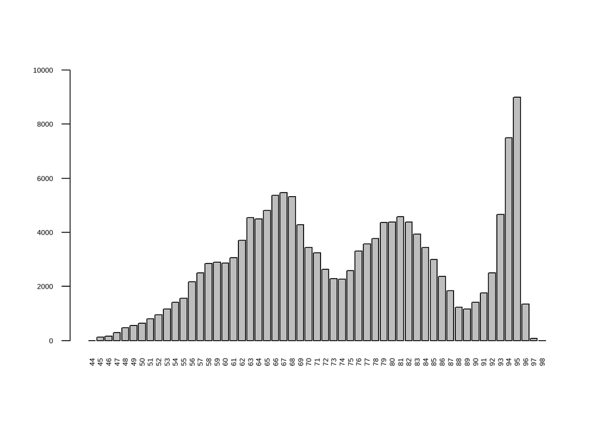

```r
barplot(table(data$remaining_lease), ylim=c(0,10000), las = 2)
```

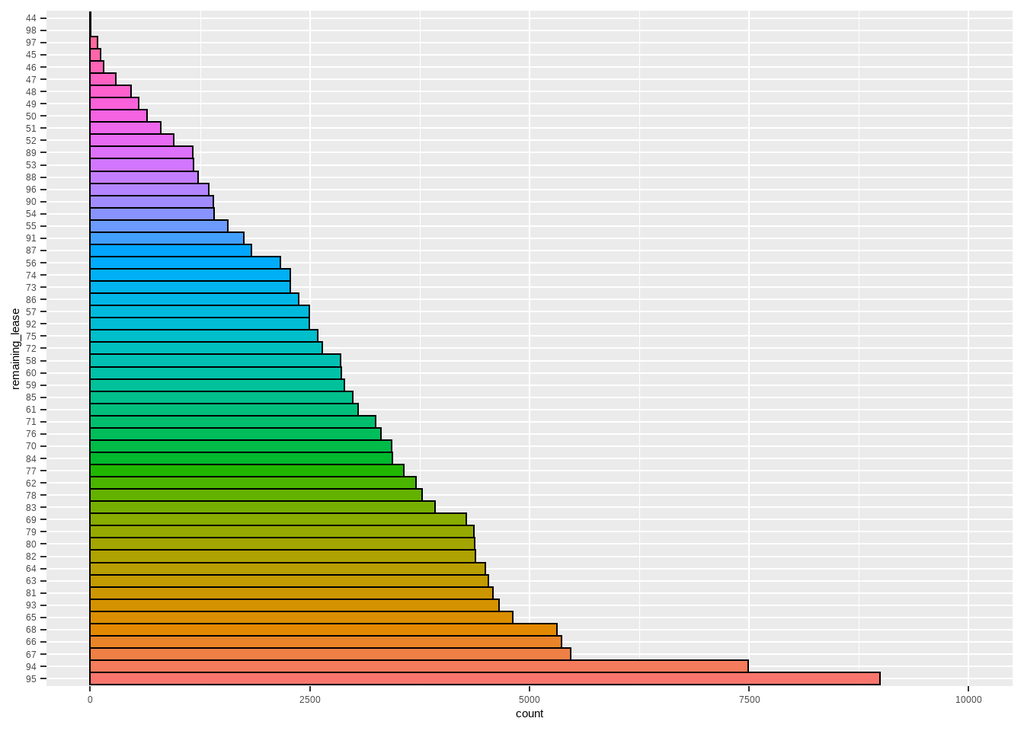

```r
data_plot <- data
data_plot$remaining_lease <- as.factor(data_plot$remaining_lease)
p <- ggplot(data_plot, aes(x = fct_infreq(remaining_lease), fill = fct_infreq(remaining_lease))) +
  geom_bar(width = 1, colour = "black", show.legend = FALSE) +
  xlab("remaining_lease")

p + coord_flip() + scale_y_continuous(limit = c(0, 10000))
```

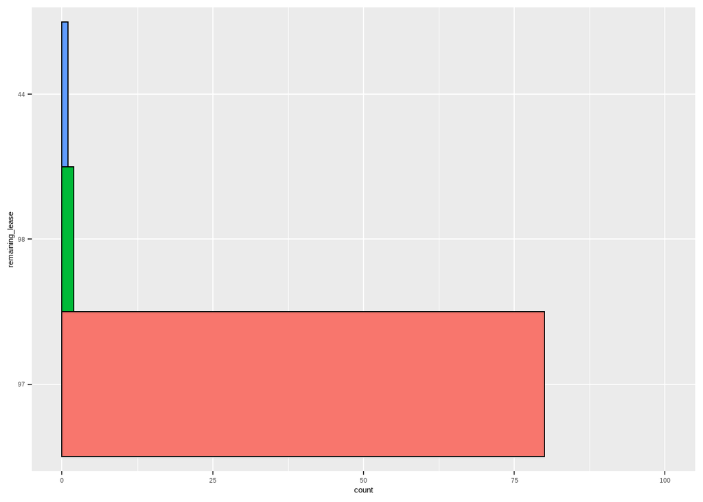

```r
# Zoom in
data_filter <- data_plot %>%
  group_by(remaining_lease) %>%
  filter(n() < 100)

p <- ggplot(data_filter, aes(x = fct_infreq(remaining_lease), fill = fct_infreq(remaining_lease))) +
  geom_bar(width = 1, colour = "black", show.legend = FALSE) +
  xlab("remaining_lease")

p + coord_flip() + scale_y_continuous(limit = c(0, 100))
```

- 95 remaining lease year has the highest transaction records, more than 8,000 rows
- 44 remaining lease year has the lowest transaction records, less than 20 rows
- remaining lease year > 96 has very low transaction records, should be due to the restriction to sell the HDB if purchased less than N years

### Drop Columns

```r
str(data)
```

```
## 'data.frame':    152455 obs. of  19 variables:
##  $ year               : Factor w/ 7 levels "2015","2016",..: 1 1 1 1 1 1 1 1 1 1 ...
##  $ month              : Factor w/ 12 levels "01","02","03",..: 1 1 1 1 1 1 1 1 1 1 ...
##  $ town               : Factor w/ 26 levels "ANG MO KIO","BEDOK",..: 1 1 1 1 1 1 1 1 1 1 ...
##  $ flat_type          : Factor w/ 7 levels "1 ROOM","2 ROOM",..: 3 3 3 3 3 3 3 3 3 3 ...
##  $ block              : chr  "174" "541" "163" "446" ...
##  $ street_name        : Factor w/ 556 levels "ADMIRALTY DR",..: 17 14 17 14 14 18 20 13 17 16 ...
##  $ storey_range       : Factor w/ 17 levels "01 TO 03","04 TO 06",..: 3 1 1 1 3 3 1 1 1 5 ...
##  $ floor_area_sqm     : num  60 68 69 68 68 67 68 68 67 68 ...
##  $ flat_model         : Factor w/ 20 levels "2-room","Adjoined flat",..: 5 12 12 12 12 12 12 12 12 12 ...
##  $ lease_commence_date: int  1986 1981 1980 1979 1980 1980 1980 1981 1978 1985 ...
##  $ remaining_lease    : int  70 65 64 63 64 64 64 65 62 69 ...
##  $ resale_price       : num  255000 275000 285000 290000 290000 ...
##  $ int_year           : int  2015 2015 2015 2015 2015 2015 2015 2015 2015 2015 ...
##  $ region             : Factor w/ 5 levels "Central","East",..: 4 4 4 4 4 4 4 4 4 4 ...
##  $ floor_area_sqm_bins: Factor w/ 13 levels "30 - 50","50 - 70",..: 2 2 2 2 2 2 2 2 2 2 ...
##  $ price_per_sqm      : num  4250 4044 4130 4265 4265 ...
##  $ new_flat_model     : Factor w/ 8 levels "2-room","Adjoined flat",..: 5 5 5 5 5 5 5 5 5 5 ...
##  $ resale_price_bins  : Factor w/ 22 levels "79000 - 140000",..: 3 4 4 4 4 4 4 4 4 4 ...
##  $ used_lease         : int  29 34 35 36 35 35 35 34 37 30 ...
```

- drop columns that are useless for prediction

```r
data <- data[,-which(names(data) %in% c("lease_commence_date","int_year","floor_area_sqm_bins","resale_price_bins","used_lease"))]
```

### Explore Cleaned Dataset

```r
summary(data)
```

```
##    year           month                town                  flat_type
##  2015:17780   07     :14672   SENGKANG   :12358   1 ROOM          :   62
##  2016:19373   08     :14426   JURONG WEST:10711   2 ROOM          : 2051
##  2017:20509   10     :14339   WOODLANDS  :10550   3 ROOM          :36960
##  2018:21561   06     :13879   TAMPINES   :10502   4 ROOM          :63202
##  2019:22186   11     :13710   PUNGGOL    : 9938   5 ROOM          :38069
##  2020:23333   09     :13662   YISHUN     : 9822   EXECUTIVE       :12046
##  2021:27713   (Other):67767   (Other)    :88574   MULTI-GENERATION:   65
##     block                       street_name       storey_range
##  Length:152455      YISHUN RING RD    :  2252   04 TO 06:35657
##  Class :character   BEDOK RESERVOIR RD:  1776   07 TO 09:32320
##  Mode  :character   ANG MO KIO AVE 10 :  1622   10 TO 12:28529
##                     PUNGGOL DR        :  1567   01 TO 03:27587
##                     PUNGGOL FIELD     :  1550   13 TO 15:14199
##                     ANG MO KIO AVE 3  :  1521   16 TO 18: 6440
##                     (Other)           :142167   (Other) : 7723
##  floor_area_sqm               flat_model    remaining_lease  resale_price
##  Min.   : 31.00   Model A          :49019   Min.   :44.00   Min.   : 140000
##  1st Qu.: 82.00   Improved         :38329   1st Qu.:65.00   1st Qu.: 343000
##  Median : 95.00   New Generation   :21252   Median :74.00   Median : 420888
##  Mean   : 97.65   Premium Apartment:16735   Mean   :74.78   Mean   : 453455
##  3rd Qu.:113.00   Simplified       : 6402   3rd Qu.:84.00   3rd Qu.: 530000
##  Max.   :280.00   Apartment        : 6054   Max.   :98.00   Max.   :1360000
##                   (Other)          :14664
##         region      price_per_sqm         new_flat_model
##  Central   :28968   Min.   : 2090   Flat         :121921
##  East      :23993   1st Qu.: 3877   Apartment    : 22866
##  North     :24075   Median : 4389   Maisonette   :  4827
##  North-East:39662   Mean   : 4683   DBSS         :  2397
##  West      :35757   3rd Qu.: 5118   Adjoined flat:   268
##                     Max.   :12903   Terrace      :    96
##                                     (Other)      :    80
```

```r
str(data)
```

```
## 'data.frame':    152455 obs. of  14 variables:
##  $ year           : Factor w/ 7 levels "2015","2016",..: 1 1 1 1 1 1 1 1 1 1 ...
##  $ month          : Factor w/ 12 levels "01","02","03",..: 1 1 1 1 1 1 1 1 1 1 ...
##  $ town           : Factor w/ 26 levels "ANG MO KIO","BEDOK",..: 1 1 1 1 1 1 1 1 1 1 ...
##  $ flat_type      : Factor w/ 7 levels "1 ROOM","2 ROOM",..: 3 3 3 3 3 3 3 3 3 3 ...
##  $ block          : chr  "174" "541" "163" "446" ...
##  $ street_name    : Factor w/ 556 levels "ADMIRALTY DR",..: 17 14 17 14 14 18 20 13 17 16 ...
##  $ storey_range   : Factor w/ 17 levels "01 TO 03","04 TO 06",..: 3 1 1 1 3 3 1 1 1 5 ...
##  $ floor_area_sqm : num  60 68 69 68 68 67 68 68 67 68 ...
##  $ flat_model     : Factor w/ 20 levels "2-room","Adjoined flat",..: 5 12 12 12 12 12 12 12 12 12 ...
##  $ remaining_lease: int  70 65 64 63 64 64 64 65 62 69 ...
##  $ resale_price   : num  255000 275000 285000 290000 290000 ...
##  $ region         : Factor w/ 5 levels "Central","East",..: 4 4 4 4 4 4 4 4 4 4 ...
##  $ price_per_sqm  : num  4250 4044 4130 4265 4265 ...
##  $ new_flat_model : Factor w/ 8 levels "2-room","Adjoined flat",..: 5 5 5 5 5 5 5 5 5 5 ...
```

### Export Cleaned Dataset

```r
write.csv(data,"../data/data_clean.csv", row.names = FALSE)
```